# PROJECT -----> FOOTBALL DATA ANALYSIS

## Problem Identification

In this project, we will define the problem statement and it's goals using SMART framework, then we will analyzed it further by breaking down the problem into question. Here, we will try to roleplay as a Data Analyst working at Football Club

Topic : Football

### Problem statement

"The football club is facing financials difficulties (trying to recover from debt). The goal is to increase the overall market value of players by 15% within the upcoming season by analyzing and optimizing player performance metrics and market value determinants."

#### Breaking Down The Problem Main problem:- Improving player and club market value as metrics of financial recovery.

Football player:  
Who are the players with the highest market value right now?  
Do players with specific physical attributes command higher market values?  
What factors contribute most to a player's market value (age, position, performance metrics)?  
Where are the players with the highest market values from (country)?  
Why do some players have a higher market value despite similar performance metrics (goals, assists, minutes played)?  
How can training and development programs be optimized to improve players market value?  
League:  
Which league contribute to highest market value right now?  
Team :  
Which club has the highest market value right now?

```python
# Import Library
import numpy as np
import pandas as pd
import seaborn as sns
import matplotlib.pyplot as plt
import matplotlib.ticker as ticker
from datetime import datetime
import warnings
warnings.filterwarnings("ignore")
from scipy import stats
```

```python
# Load CSV into dataframes
appearances_df = pd.read_csv(r"C:\Users\LENOVO\Desktop\top mentor\kaggle project\appearances.csv", encoding="latin1")
```

```python
print(appearances_df)
```

```
          appearance_id  game_id  player_id  player_club_id  \
0         2231978_38004  2231978      38004             853
1         2233748_79232  2233748      79232            8841
2         2234413_42792  2234413      42792            6251
3         2234418_73333  2234418      73333            1274
4        2234421_122011  2234421     122011             195
...                 ...      ...        ...             ...
1824003  4814366_583189  4814366     583189             762
1824004  4814366_683840  4814366     683840             131
1824005  4814366_705395  4814366     705395             131
1824006  4814366_962110  4814366     962110             131
1824007  4839900_312891  4839900     312891             964

         player_current_club_id        date         player_name  \
0                           235  2012-07-03   AurÃ©lien Joachim
```

[output cut: 38 more lines]

```python
players_df = pd.read_csv(r"C:\Users\LENOVO\Desktop\top mentor\kaggle project\players.csv", encoding="latin1")
```

```python
print(players_df)
```

```
       player_id  first_name      last_name                name  last_season  \
0             10    Miroslav          Klose      Miroslav Klose         2015
1             26       Roman   Weidenfeller  Roman Weidenfeller         2017
2             65     Dimitar       Berbatov    Dimitar Berbatov         2015
3             77         NaN         LÃºcio              LÃºcio         2012
4             80         Tom         Starke          Tom Starke         2017
...          ...         ...            ...                 ...          ...
37574    1494766     Saikuba          Jarju       Saikuba Jarju         2025
37575    1497653        Bara  Sapoko Ndiaye  Bara Sapoko Ndiaye         2025
37576    1500143      Moussa           Kone         Moussa Kone         2025
37577    1507561  Mouhamadou           Sall     Mouhamadou Sall         2025
37578    1510255      Miguel          Silva        Miguel Silva         2025

       current_club_id         player_code    country_of_birth city_of_birth  \
0                  398      miroslav-klose              Poland         Opole
```

[output cut: 103 more lines]

```python
games_df = pd.read_csv(r"C:\Users\LENOVO\Desktop\top mentor\kaggle project\games.csv", encoding="latin1")
```

```python
print(games_df)
```

```
       game_id competition_id  season        round        date  home_club_id  \
0      1026846           FIWC    2009  Round of 16  2010-06-26          3449
1      1026847           FIWC    2009  Round of 16  2010-06-27          3437
2      1027001           FIWC    2009  Round of 16  2010-06-26          3505
3      1027002           FIWC    2009  Round of 16  2010-06-27          3262
4      1027048           FIWC    2009  Round of 16  2010-06-28          3379
...        ...            ...     ...          ...         ...           ...
80502   986818           FIWC    2009      Group F  2010-06-24          3581
80503   986819           FIWC    2009      Group G  2010-06-25          3300
80504   986820           FIWC    2009      Group G  2010-06-25         15457
80505   986821           FIWC    2009      Group H  2010-06-25          3700
80506   986822           FIWC    2009      Group H  2010-06-25          3384

       away_club_id  home_club_goals  away_club_goals  home_club_position  \
0              3589                2                1                 NaN
```

[output cut: 64 more lines]

```python
full_players_info = players_df.merge(appearances_df, on='player_id')
full_players_info = full_players_info.merge(games_df[['game_id','season']], on='game_id')
full_players_info = full_players_info.sort_values(by='market_value_in_eur', ascending=False)
print(full_players_info)
```

```
         player_id         first_name last_name                     name  \
1384936     342229             Kylian   MbappÃ©           Kylian MbappÃ©
1384935     342229             Kylian   MbappÃ©           Kylian MbappÃ©
1384934     342229             Kylian   MbappÃ©           Kylian MbappÃ©
1384532     342229             Kylian   MbappÃ©           Kylian MbappÃ©
1384531     342229             Kylian   MbappÃ©           Kylian MbappÃ©
...            ...                ...       ...                      ...
1823885    1381775              Anton   Vydrych            Anton Vydrych
1823886    1381775              Anton   Vydrych            Anton Vydrych
1823958    1397259  Abdurrahman Burak     Sayin  Abdurrahman Burak Sayin
1823959    1406923          Beytullah     Gezer          Beytullah Gezer
1823970    1414670            Ismaila     Manga            Ismaila Manga

         last_season  current_club_id              player_code  \
1384936         2025              418            kylian-mbappe
```

[output cut: 64 more lines]

```python
full_players_info.shape
```

```
(1824004, 39)
```

```python
full_players_info.describe()
```

|  | player_id | last_season | current_club_id | height_in_cm | international_caps | international_goals | current_national_team_id | market_value_in_eur | highest_market_value_in_eur | game_id | player_club_id | player_current_club_id | yellow_cards | red_cards | goals | assists | minutes_played | season |
| --- | --- | --- | --- | --- | --- | --- | --- | --- | --- | --- | --- | --- | --- | --- | --- | --- | --- | --- |
| count | 1.824004e+06 | 1.824004e+06 | 1.824004e+06 | 1.807823e+06 | 808896.000000 | 808896.000000 | 284041.000000 | 1.821635e+06 | 1.821635e+06 | 1.824004e+06 | 1.824004e+06 | 1.824004e+06 | 1.824004e+06 | 1.824004e+06 | 1.824004e+06 | 1.824004e+06 | 1.824004e+06 | 1.824004e+06 |
| mean | 2.295411e+05 | 2.022004e+03 | 4.537997e+03 | 1.822050e+02 | 26.123073 | 3.706348 | 4313.699315 | 4.419577e+06 | 1.280974e+07 | 3.257908e+06 | 3.222054e+03 | 4.537997e+03 | 1.460501e-01 | 3.804268e-03 | 9.552446e-02 | 7.518843e-02 | 6.871803e+01 | 2.018461e+03 |
| std | 2.140824e+05 | 3.494616e+00 | 1.219846e+04 | 6.667172e+00 | 32.270785 | 9.699994 | 4973.896057 | 1.190015e+07 | 2.045513e+07 | 7.332244e+05 | 8.770823e+03 | 1.219846e+04 | 3.640028e-01 | 6.156133e-02 | 3.301505e-01 | 2.849228e-01 | 3.012336e+01 | 3.975933e+00 |
| min | 1.000000e+01 | 2.012000e+03 | 2.000000e+00 | 1.800000e+01 | 0.000000 | 0.000000 | 3262.000000 | 1.000000e+04 | 1.000000e+04 | 2.211607e+06 | 1.000000e+00 | 2.000000e+00 | 0.000000e+00 | 0.000000e+00 | 0.000000e+00 | 0.000000e+00 | 1.000000e+00 | 2.012000e+03 |
| 25% | 6.060400e+04 | 2.020000e+03 | 3.370000e+02 | 1.780000e+02 | 3.000000 | 0.000000 | 3379.000000 | 2.500000e+05 | 1.500000e+06 | 2.604077e+06 | 2.810000e+02 | 3.370000e+02 | 0.000000e+00 | 0.000000e+00 | 0.000000e+00 | 0.000000e+00 | 4.500000e+01 | 2.015000e+03 |
| 50% | 1.666010e+05 | 2.023000e+03 | 9.400000e+02 | 1.820000e+02 | 13.000000 | 1.000000 | 3439.000000 | 7.000000e+05 | 5.000000e+06 | 3.195024e+06 | 8.200000e+02 | 9.400000e+02 | 0.000000e+00 | 0.000000e+00 | 0.000000e+00 | 0.000000e+00 | 9.000000e+01 | 2.019000e+03 |
| 75% | 3.377150e+05 | 2.025000e+03 | 2.727000e+03 | 1.870000e+02 | 39.000000 | 3.000000 | 3561.000000 | 3.000000e+06 | 1.500000e+07 | 3.852654e+06 | 2.425000e+03 | 2.727000e+03 | 0.000000e+00 | 0.000000e+00 | 0.000000e+00 | 0.000000e+00 | 9.000000e+01 | 2.022000e+03 |
| max | 1.510255e+06 | 2.025000e+03 | 1.270010e+05 | 2.070000e+02 | 226.000000 | 143.000000 | 53982.000000 | 2.000000e+08 | 2.000000e+08 | 4.839900e+06 | 1.328770e+05 | 1.270010e+05 | 2.000000e+00 | 1.000000e+00 | 6.000000e+00 | 6.000000e+00 | 1.480000e+02 | 2.025000e+03 |

```python
full_players_info.info(verbose=True, show_counts=True)
```

```
<class 'pandas.DataFrame'>
Index: 1824004 entries, 1384936 to 1823970
Data columns (total 39 columns):
 #   Column                                Non-Null Count    Dtype
---  ------                                --------------    -----
 0   player_id                             1824004 non-null  int64
 1   first_name                            1689773 non-null  str
 2   last_name                             1824004 non-null  str
 3   name                                  1824004 non-null  str
 4   last_season                           1824004 non-null  int64
 5   current_club_id                       1824004 non-null  int64
 6   player_code                           1824004 non-null  str
 7   country_of_birth                      1786579 non-null  str
 8   city_of_birth                         1806160 non-null  str
 9   country_of_citizenship                1804302 non-null  str
```

[output cut: 31 more lines]

```python
columns_to_drop = ['highest_market_value_in_eur','country_of_birth','international_goals','current_national_team_id','last_season','contract_expiration_date','player_name',
                    'agent_name' ,'appearance_id', 'game_id', 'player_id', 'player_club_id', 'player_current_club_id', 'competition_id',
                    'first_name', 'last_name', 'current_club_id', 'player_code', 'city_of_birth', 'sub_position', 'image_url', 'url', 'date','international_caps']

full_players_info = full_players_info.drop(columns=columns_to_drop)
```

```python
print(full_players_info)
```

```
                            name country_of_citizenship        date_of_birth  \
1384936           Kylian MbappÃ©                 France  1998-12-20 00:00:00
1384935           Kylian MbappÃ©                 France  1998-12-20 00:00:00
1384934           Kylian MbappÃ©                 France  1998-12-20 00:00:00
1384532           Kylian MbappÃ©                 France  1998-12-20 00:00:00
1384531           Kylian MbappÃ©                 France  1998-12-20 00:00:00
...                          ...                    ...                  ...
1823885            Anton Vydrych                Ukraine  2008-01-30 00:00:00
1823886            Anton Vydrych                Ukraine  2008-01-30 00:00:00
1823958  Abdurrahman Burak Sayin            Netherlands  2006-08-23 00:00:00
1823959          Beytullah Gezer               TÃ¼rkiye  2010-05-26 00:00:00
1823970            Ismaila Manga                Senegal  2007-05-15 00:00:00

         position   foot  height_in_cm current_club_domestic_competition_id  \
1384936    Attack  right         180.0                                  ES1
```

[output cut: 38 more lines]

```python
full_players_info_2023 = full_players_info.loc[full_players_info['season'] == 2023]

full_players_info_2023 = full_players_info_2023.drop('season', axis=1)

full_players_info_2023.head()
```

|  | name | country_of_citizenship | date_of_birth | position | foot | height_in_cm | current_club_domestic_competition_id | current_club_name | market_value_in_eur | yellow_cards | red_cards | goals | assists | minutes_played |
| --- | --- | --- | --- | --- | --- | --- | --- | --- | --- | --- | --- | --- | --- | --- |
| 1519404 | Erling Haaland | Norway | 2000-07-21 00:00:00 | Attack | left | 195.0 | GB1 | Manchester City Football Club | 200000000.0 | 0 | 0 | 0 | 0 | 82 |
| 1519403 | Erling Haaland | Norway | 2000-07-21 00:00:00 | Attack | left | 195.0 | GB1 | Manchester City Football Club | 200000000.0 | 0 | 0 | 4 | 0 | 82 |
| 1519402 | Erling Haaland | Norway | 2000-07-21 00:00:00 | Attack | left | 195.0 | GB1 | Manchester City Football Club | 200000000.0 | 0 | 0 | 1 | 0 | 28 |
| 1519401 | Erling Haaland | Norway | 2000-07-21 00:00:00 | Attack | left | 195.0 | GB1 | Manchester City Football Club | 200000000.0 | 0 | 0 | 0 | 0 | 90 |
| 1519400 | Erling Haaland | Norway | 2000-07-21 00:00:00 | Attack | left | 195.0 | GB1 | Manchester City Football Club | 200000000.0 | 0 | 0 | 1 | 0 | 81 |

```python
player_stats_2023 = full_players_info_2023.groupby('name').agg({
    'yellow_cards': 'sum',
    'red_cards': 'sum',
    'goals': 'sum',
    'assists': 'sum',
    'minutes_played': 'sum'})

player_stats_2023 = player_stats_2023.reset_index()

player_stats_2023
```

|  | name | yellow_cards | red_cards | goals | assists | minutes_played |
| --- | --- | --- | --- | --- | --- | --- |
| 0 | Aaron Appindangoyé | 1 | 0 | 1 | 2 | 2688 |
| 1 | Aaron Brown | 0 | 0 | 0 | 0 | 1 |
| 2 | Aaron Cresswell | 3 | 0 | 1 | 0 | 928 |
| 3 | Aaron Donnelly | 2 | 0 | 0 | 2 | 1446 |
| 4 | Aaron Hickey | 5 | 0 | 0 | 0 | 720 |
| ... | ... | ... | ... | ... | ... | ... |
| 7144 | Ä°smail ÇokçalÄ±Å | 0 | 0 | 0 | 1 | 1077 |
| 7145 | Ä°zzet Topatar | 1 | 0 | 0 | 0 | 39 |
| 7146 | Ä°zzet Çelik | 0 | 0 | 0 | 0 | 44 |
| 7147 | Åamil Öztürk | 0 | 0 | 0 | 0 | 1 |
| 7148 | Åener ÖzbayraklÄ± | 0 | 0 | 0 | 0 | 127 |

7149 rows × 6 columns

```python
full_players_info_2023.drop(columns=['yellow_cards', 'red_cards', 'goals', 'assists', 'minutes_played'], inplace=True)

full_players_info_2023 = full_players_info_2023.merge(player_stats_2023, how='left', on='name')
```

```python
print("Number of duplicate values :",full_players_info_2023.duplicated().sum())
```

```
Number of duplicate values : 135660
```

```python
full_players_info_2023 = full_players_info_2023.drop_duplicates()

full_players_info_2023
```

|  | name | country_of_citizenship | date_of_birth | position | foot | height_in_cm | current_club_domestic_competition_id | current_club_name | market_value_in_eur | yellow_cards | red_cards | goals | assists | minutes_played |
| --- | --- | --- | --- | --- | --- | --- | --- | --- | --- | --- | --- | --- | --- | --- |
| 0 | Erling Haaland | Norway | 2000-07-21 00:00:00 | Attack | left | 195.0 | GB1 | Manchester City Football Club | 200000000.0 | 1 | 0 | 38 | 5 | 3745 |
| 45 | Kylian Mbappé | France | 1998-12-20 00:00:00 | Attack | right | 180.0 | ES1 | Real Madrid Club de Fútbol | 200000000.0 | 5 | 0 | 36 | 7 | 3329 |
| 64 | Lamine Yamal | Spain | 2007-07-13 00:00:00 | Attack | left | 180.0 | ES1 | Futbol Club Barcelona | 200000000.0 | 6 | 0 | 7 | 9 | 2957 |
| 137 | Pedri | Spain | 2002-11-25 00:00:00 | Midfield | right | 174.0 | ES1 | Futbol Club Barcelona | 150000000.0 | 3 | 0 | 4 | 5 | 2027 |
| 148 | Vinicius Junior | Brazil | 2000-07-12 00:00:00 | Attack | right | 176.0 | ES1 | Real Madrid Club de Fútbol | 150000000.0 | 11 | 0 | 24 | 11 | 3084 |
| ... | ... | ... | ... | ... | ... | ... | ... | ... | ... | ... | ... | ... | ... | ... |
| 142850 | Vladyslav Kramar | Ukraine | 2005-12-06 00:00:00 | Midfield | right | 185.0 | UKR1 | FK Polissya Zhytomyr | NaN | 0 | 0 | 0 | 0 | 2 |
| 142852 | Ahmet Mert KoÅar | Türkiye | 2006-11-29 00:00:00 | Attack | right | 189.0 | TR1 | Pendikspor | NaN | 0 | 0 | 0 | 0 | 1 |
| 142853 | Bünyamin Çetinkaya | Türkiye | 2009-09-08 00:00:00 | Attack | NaN | NaN | TR1 | KasÄ±mpaÅa A.Å. | NaN | 0 | 0 | 0 | 0 | 1 |
| 142854 | Sjors-Lowis Hermsen | Netherlands | 2007-06-12 00:00:00 | Missing | NaN | 175.0 | NL1 | Fortuna Sittardia Combinatie | NaN | 0 | 0 | 0 | 0 | 1 |
| 142855 | Tymur Butenko | Ukraine | 2006-11-14 00:00:00 | Attack | right | 174.0 | UKR1 | FK Kryvbas Kryvyi Rig | NaN | 0 | 0 | 0 | 0 | 9 |

7196 rows × 14 columns

```python
full_players_info_2023.isnull().sum()
```

```
name                                      0
country_of_citizenship                    0
date_of_birth                             2
position                                  0
foot                                    141
height_in_cm                            144
current_club_domestic_competition_id    271
current_club_name                       271
market_value_in_eur                     102
yellow_cards                              0
red_cards                                 0
goals                                     0
assists                                   0
minutes_played                            0
dtype: int64
```

```python
full_players_info_2023 = full_players_info_2023.dropna()

full_players_info_2023 = full_players_info_2023.loc[full_players_info_2023["position"] != "Missing"]
```

```python
full_players_info_2023 = full_players_info_2023.reset_index()
full_players_info_2023 = full_players_info_2023.drop(columns='index')

full_players_info_2023.head(10)
```

|  | name | country_of_citizenship | date_of_birth | position | foot | height_in_cm | current_club_domestic_competition_id | current_club_name | market_value_in_eur | yellow_cards | red_cards | goals | assists | minutes_played |
| --- | --- | --- | --- | --- | --- | --- | --- | --- | --- | --- | --- | --- | --- | --- |
| 0 | Erling Haaland | Norway | 2000-07-21 00:00:00 | Attack | left | 195.0 | GB1 | Manchester City Football Club | 200000000.0 | 1 | 0 | 38 | 5 | 3745 |
| 1 | Kylian Mbappé | France | 1998-12-20 00:00:00 | Attack | right | 180.0 | ES1 | Real Madrid Club de Fútbol | 200000000.0 | 5 | 0 | 36 | 7 | 3329 |
| 2 | Lamine Yamal | Spain | 2007-07-13 00:00:00 | Attack | left | 180.0 | ES1 | Futbol Club Barcelona | 200000000.0 | 6 | 0 | 7 | 9 | 2957 |
| 3 | Pedri | Spain | 2002-11-25 00:00:00 | Midfield | right | 174.0 | ES1 | Futbol Club Barcelona | 150000000.0 | 3 | 0 | 4 | 5 | 2027 |
| 4 | Vinicius Junior | Brazil | 2000-07-12 00:00:00 | Attack | right | 176.0 | ES1 | Real Madrid Club de Fútbol | 150000000.0 | 11 | 0 | 24 | 11 | 3084 |
| 5 | Jude Bellingham | England | 2003-06-29 00:00:00 | Midfield | right | 186.0 | ES1 | Real Madrid Club de Fútbol | 140000000.0 | 9 | 1 | 23 | 13 | 3644 |
| 6 | Michael Olise | France | 2001-12-12 00:00:00 | Attack | left | 184.0 | L1 | FC Bayern München | 140000000.0 | 0 | 0 | 10 | 6 | 1278 |
| 7 | Declan Rice | England | 1999-01-14 00:00:00 | Midfield | right | 188.0 | GB1 | Arsenal Football Club | 120000000.0 | 7 | 0 | 7 | 10 | 4241 |
| 8 | Federico Valverde | Uruguay | 1998-07-22 00:00:00 | Midfield | right | 182.0 | ES1 | Real Madrid Club de Fútbol | 120000000.0 | 2 | 0 | 3 | 8 | 4280 |
| 9 | Bukayo Saka | England | 2001-09-05 00:00:00 | Attack | left | 178.0 | GB1 | Arsenal Football Club | 120000000.0 | 4 | 0 | 20 | 14 | 3841 |

```python
full_players_info_2023['date_of_birth'] = pd.to_datetime(full_players_info_2023['date_of_birth'])
```

```python
now = datetime.now()

full_players_info_2023['age'] = (now - full_players_info_2023['date_of_birth']).dt.days / 365.25
full_players_info_2023['age'] = full_players_info_2023['age'].round().astype(int)

full_players_info_2023 = full_players_info_2023.drop(columns=['date_of_birth'])
```

```python
full_players_info_2023.head(10)
```

|  | name | country_of_citizenship | position | foot | height_in_cm | current_club_domestic_competition_id | current_club_name | market_value_in_eur | yellow_cards | red_cards | goals | assists | minutes_played | age |
| --- | --- | --- | --- | --- | --- | --- | --- | --- | --- | --- | --- | --- | --- | --- |
| 0 | Erling Haaland | Norway | Attack | left | 195.0 | GB1 | Manchester City Football Club | 200000000.0 | 1 | 0 | 38 | 5 | 3745 | 26 |
| 1 | Kylian Mbappé | France | Attack | right | 180.0 | ES1 | Real Madrid Club de Fútbol | 200000000.0 | 5 | 0 | 36 | 7 | 3329 | 27 |
| 2 | Lamine Yamal | Spain | Attack | left | 180.0 | ES1 | Futbol Club Barcelona | 200000000.0 | 6 | 0 | 7 | 9 | 2957 | 19 |
| 3 | Pedri | Spain | Midfield | right | 174.0 | ES1 | Futbol Club Barcelona | 150000000.0 | 3 | 0 | 4 | 5 | 2027 | 23 |
| 4 | Vinicius Junior | Brazil | Attack | right | 176.0 | ES1 | Real Madrid Club de Fútbol | 150000000.0 | 11 | 0 | 24 | 11 | 3084 | 26 |
| 5 | Jude Bellingham | England | Midfield | right | 186.0 | ES1 | Real Madrid Club de Fútbol | 140000000.0 | 9 | 1 | 23 | 13 | 3644 | 23 |
| 6 | Michael Olise | France | Attack | left | 184.0 | L1 | FC Bayern München | 140000000.0 | 0 | 0 | 10 | 6 | 1278 | 24 |
| 7 | Declan Rice | England | Midfield | right | 188.0 | GB1 | Arsenal Football Club | 120000000.0 | 7 | 0 | 7 | 10 | 4241 | 27 |
| 8 | Federico Valverde | Uruguay | Midfield | right | 182.0 | ES1 | Real Madrid Club de Fútbol | 120000000.0 | 2 | 0 | 3 | 8 | 4280 | 28 |
| 9 | Bukayo Saka | England | Attack | left | 178.0 | GB1 | Arsenal Football Club | 120000000.0 | 4 | 0 | 20 | 14 | 3841 | 25 |

```python
full_players_info_2023.columns
```

```
Index(['name', 'country_of_citizenship', 'position', 'foot', 'height_in_cm',
       'current_club_domestic_competition_id', 'current_club_name',
       'market_value_in_eur', 'yellow_cards', 'red_cards', 'goals', 'assists',
       'minutes_played', 'age'],
      dtype='str')
```

```python
full_players_info_2023.to_csv('full_players_info_2023.csv',index=False)
```

# Who are the players with the highest market value right now?

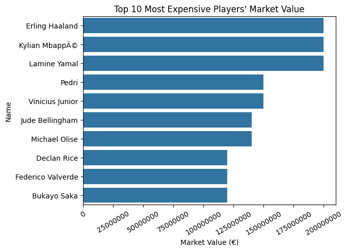

```python
sns.barplot(data=full_players_info_2023.sort_values(by='market_value_in_eur', ascending=False).head(10), x='market_value_in_eur', y='name', edgecolor="none")

def format_func(value, tick_number):
    return f'{value:.0f}'

pvl = plt.gca()

pvl.xaxis.set_major_formatter(ticker.FuncFormatter(format_func))

plt.xlabel('Market Value (€)')
plt.xticks(rotation=30)
plt.ylabel('Name')
plt.title("Top 10 Most Expensive Players' Market Value")

plt.show()
```

# Do players with specific physical attributes command higher market values?

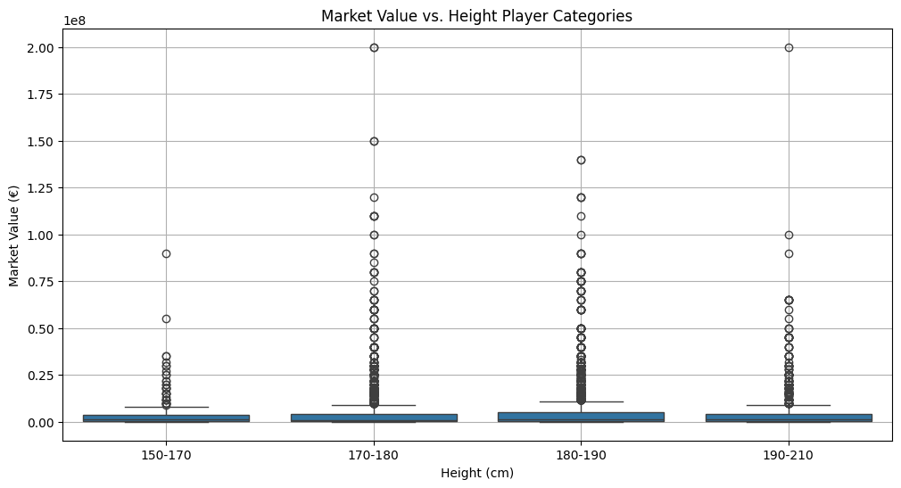

```python
df_copy = full_players_info_2023.copy()

bins_height = [150, 170, 180, 190, 210]
labels_height = ['150-170', '170-180', '180-190', '190-210']

df_copy['height_category'] = pd.cut(df_copy['height_in_cm'], bins=bins_height, labels=labels_height)

plt.figure(figsize=(12, 6))
sns.boxplot(x='height_category', y='market_value_in_eur', data=df_copy)
plt.xlabel('Height (cm)')
plt.ylabel('Market Value (€)')
plt.title('Market Value vs. Height Player Categories')
plt.grid(True)
plt.show()
```

```python
medians = df_copy.groupby('height_category')['market_value_in_eur'].median()

for category, median in zip(labels_height, medians):
  print(f"Median Market Value for {category} cm: {median:.2f} Million €")
```

```
Median Market Value for 150-170 cm: 1400000.00 Million €
Median Market Value for 170-180 cm: 1000000.00 Million €
Median Market Value for 180-190 cm: 1200000.00 Million €
Median Market Value for 190-210 cm: 1200000.00 Million €
```

```python
df_copy.groupby('height_category')['market_value_in_eur'].describe()
```

| height_category | count | mean | std | min | 25% | 50% | 75% | max |
| --- | --- | --- | --- | --- | --- | --- | --- | --- |
| 150-170 | 279.0 | 4.137366e+06 | 8.604746e+06 | 25000.0 | 400000.0 | 1400000.0 | 3750000.0 | 90000000.0 |
| 170-180 | 2366.0 | 5.607959e+06 | 1.373793e+07 | 10000.0 | 400000.0 | 1000000.0 | 4000000.0 | 200000000.0 |
| 180-190 | 3193.0 | 5.586126e+06 | 1.212970e+07 | 25000.0 | 400000.0 | 1200000.0 | 5000000.0 | 140000000.0 |
| 190-210 | 807.0 | 5.841016e+06 | 1.327632e+07 | 25000.0 | 400000.0 | 1200000.0 | 4000000.0 | 200000000.0 |

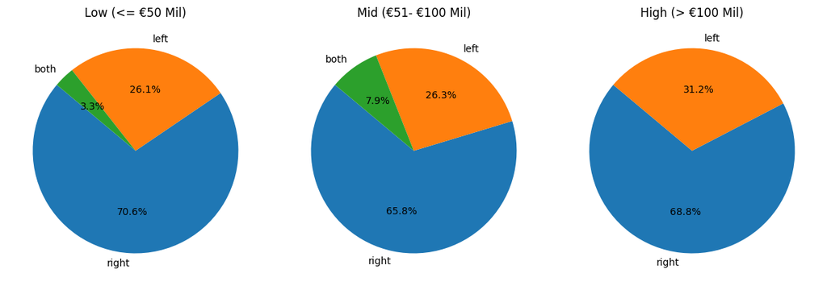

```python
ranges = [
    ('Low (<= €50 Mil)', full_players_info_2023[(full_players_info_2023['market_value_in_eur'] <= 50000000)]['foot'].value_counts()),
    ('Mid (€51- €100 Mil)', full_players_info_2023[(full_players_info_2023['market_value_in_eur'] > 50000000) & (full_players_info_2023['market_value_in_eur'] <= 100000000)]['foot'].value_counts()),
    ('High (> €100 Mil)', full_players_info_2023[full_players_info_2023['market_value_in_eur'] > 100000000]['foot'].value_counts())]
fig, axes = plt.subplots(1, 3, figsize=(12, 4))

pie_charts = []
for i, (range_label, data) in enumerate(ranges):
    pie_chart, _, _ = axes[i].pie(data, labels=data.index, autopct='%1.1f%%', startangle=140)
    pie_charts.append(pie_chart)
    axes[i].set_title(range_label)

plt.tight_layout()
plt.show()
```

# What factors contribute most to a player's market value (age, position, performance metrics)

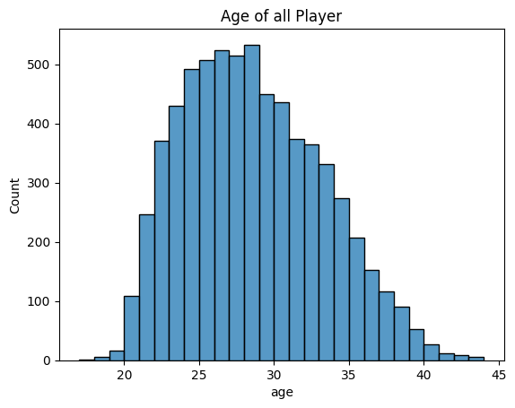

```
Mean player age :  28.130323551542514
Median player age :  28.0
```

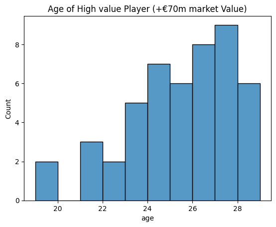

```
Mean player age (High value) :  25.0
Median player age (High value) :  25.0
```

```python
plt.title("Age of all Player")
sns.histplot(x='age',data=full_players_info_2023, binwidth=1)
plt.show()

print("Mean player age : ", full_players_info_2023['age'].mean())
print("Median player age : ", full_players_info_2023['age'].median())

High_value_full_players_info_2023 = full_players_info_2023[full_players_info_2023['market_value_in_eur']>70000000]
plt.title("Age of High value Player (+€70m market Value)")
sns.histplot(x='age',data=High_value_full_players_info_2023, binwidth=1)
plt.show()

print("Mean player age (High value) : ", High_value_full_players_info_2023['age'].mean())
print("Median player age (High value) : ", High_value_full_players_info_2023['age'].median())
```

```python
age_series = full_players_info_2023['age']

age_stats = age_series.describe()

variance = age_series.var()
skewness = age_series.skew()
kurtosis = age_series.kurtosis()
mode = age_series.mode().iloc[0]  # Get the first mode
iqr = age_series.quantile(0.75) - age_series.quantile(0.25)

additional_stats = pd.DataFrame({
    'count': [age_stats['count']],
    'mean': [age_stats['mean']],
    'std': [age_stats['std']],
    'min': [age_stats['min']],
    'median': [age_stats['50%']],
    'max': [age_stats['max']],
    'variance': [variance],
    'skewness': [skewness],
    'kurtosis': [kurtosis],
    'mode': [mode],
    'IQR': [iqr]})

print(additional_stats)
```

```
    count       mean       std   min  median   max   variance  skewness  \
0  6645.0  28.130324  4.640105  17.0    28.0  44.0  21.530575  0.376979

   kurtosis  mode  IQR
0 -0.475607    28  7.0
```

```python
positions = full_players_info_2023['position'].unique()
market_values = [full_players_info_2023[full_players_info_2023['position'] == position]['market_value_in_eur'] for position in positions]

anova_result = stats.f_oneway(*market_values)

print(f"ANOVA F-statistic: {anova_result.statistic}")
print(f"ANOVA p-value: {anova_result.pvalue}")
```

```
ANOVA F-statistic: 13.184303249490153
ANOVA p-value: 1.4013527673747846e-08
```

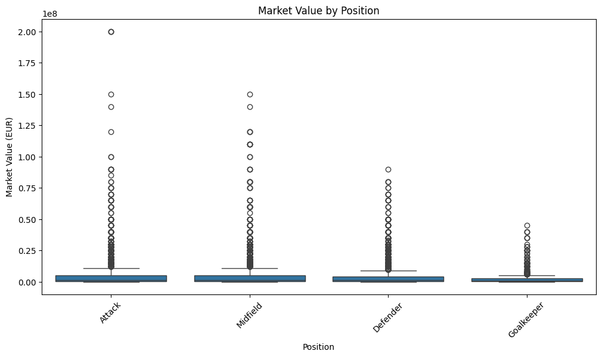

```python
plt.figure(figsize=(12, 6))
sns.boxplot(x='position', y='market_value_in_eur', data=full_players_info_2023)
plt.title('Market Value by Position')
plt.xlabel('Position')
plt.ylabel('Market Value (EUR)')
plt.xticks(rotation=45)
plt.show()
```

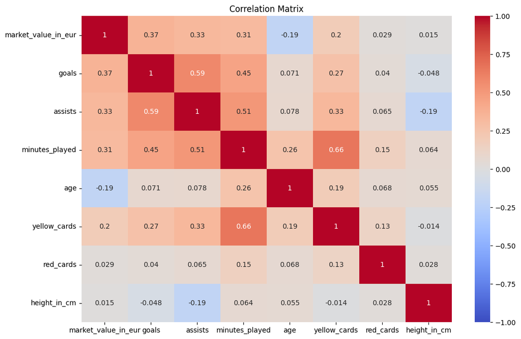

```python
plt.figure(figsize=(12, 8))
corr_matrix = full_players_info_2023[['market_value_in_eur', 'goals', 'assists', 'minutes_played', 'age', 'yellow_cards', 'red_cards', 'height_in_cm']].corr()
sns.heatmap(corr_matrix, annot=True, cmap='coolwarm', vmin=-1, vmax=1)
plt.title('Correlation Matrix')
plt.show()
```

# Where are the players with the highest market values from (country)?

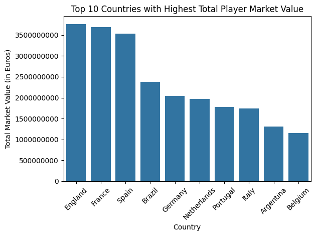

```python
country_market_value = full_players_info_2023.groupby('country_of_citizenship')['market_value_in_eur'].sum().sort_values(ascending=False)

top_10_countries = country_market_value.head(10)

sns.barplot(x=top_10_countries.index, y=top_10_countries.values)

def format_func(value, tick_number):
    return f'{value:.0f}'

ax = plt.gca()

ax.yaxis.set_major_formatter(ticker.FuncFormatter(format_func))

plt.xlabel('Country')
plt.ylabel('Total Market Value (in Euros)')
plt.xticks(rotation=45)
plt.title('Top 10 Countries with Highest Total Player Market Value')
plt.tight_layout()

plt.show()
```

# Why do some players have a higher market value despite similar performance metrics (goals, assists, minutes played)?

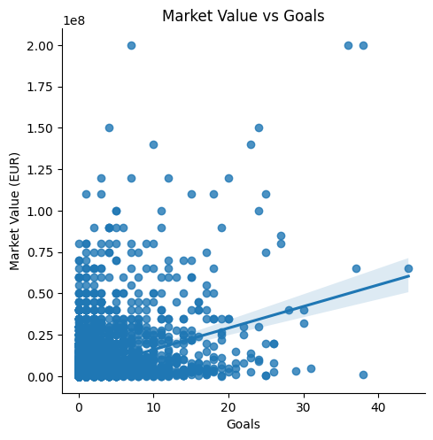

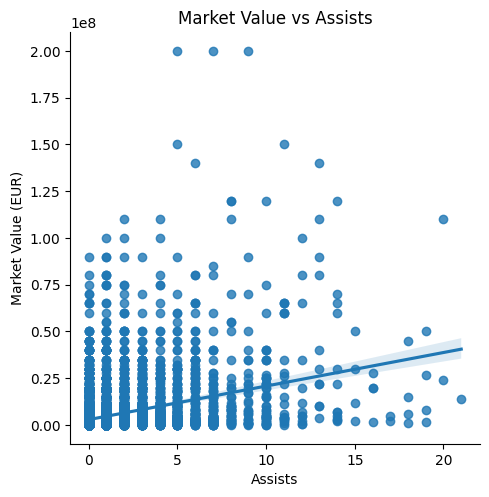

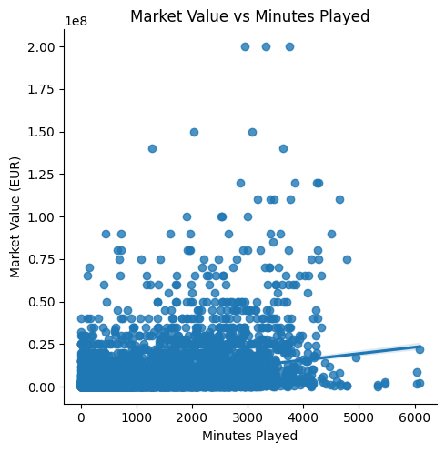

```python
# Scatter plot: Market Value vs Goals
plt.figure(figsize=(10, 6))
sns.lmplot(x='goals', y='market_value_in_eur', data=full_players_info_2023)
plt.title('Market Value vs Goals')
plt.xlabel('Goals')
plt.ylabel('Market Value (EUR)')
plt.show()

# Scatter plot: Market Value vs Assists
plt.figure(figsize=(10, 6))
sns.lmplot(x='assists', y='market_value_in_eur', data=full_players_info_2023)
plt.title('Market Value vs Assists')
plt.xlabel('Assists')
plt.ylabel('Market Value (EUR)')
plt.show()

# Scatter plot: Market Value vs Minutes Played
plt.figure(figsize=(10, 6))
sns.lmplot(x='minutes_played', y='market_value_in_eur', data=full_players_info_2023)
plt.title('Market Value vs Minutes Played')
plt.xlabel('Minutes Played')
plt.ylabel('Market Value (EUR)')
plt.show()
```

# League

## Which league contribute to highest market value right now?

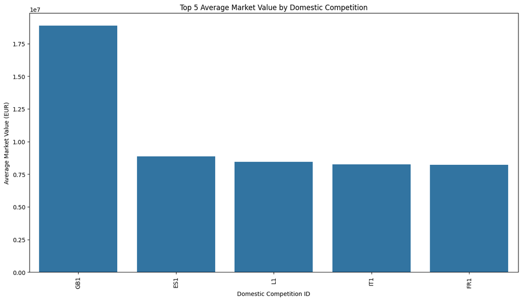

```python
plt.figure(figsize=(15, 8))
avg_market_value_by_competition = full_players_info_2023.groupby('current_club_domestic_competition_id')['market_value_in_eur'].mean().sort_values(ascending=False).head(5)
sns.barplot(x=avg_market_value_by_competition.index, y=avg_market_value_by_competition.values)
plt.title('Top 5 Average Market Value by Domestic Competition')
plt.xlabel('Domestic Competition ID')
plt.ylabel('Average Market Value (EUR)')
plt.xticks(rotation=90)
plt.show()
```

# Club Which club has the highest market value right now?

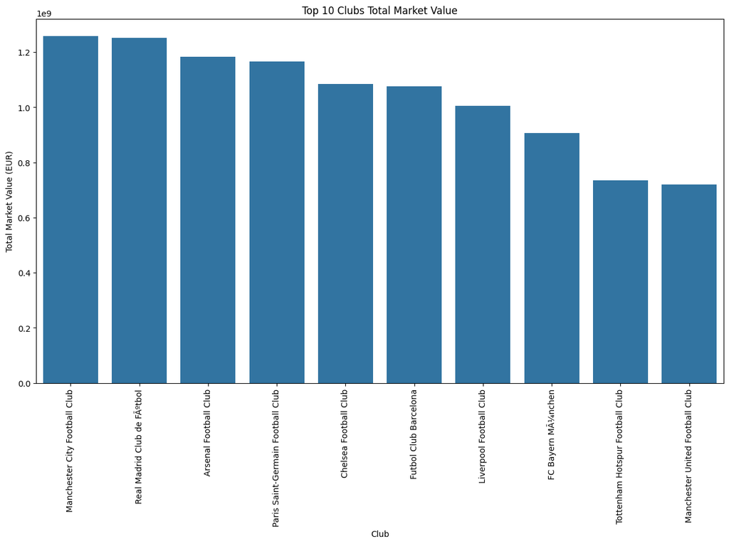

```python
plt.figure(figsize=(15, 8))
club_value = full_players_info_2023.groupby('current_club_name')['market_value_in_eur'].sum().sort_values(ascending=False).head(10)
sns.barplot(x=club_value.index, y=club_value.values)
plt.title('Top 10 Clubs Total Market Value')
plt.xlabel('Club')
plt.ylabel('Total Market Value (EUR)')
plt.xticks(rotation=90)
plt.show()
```

```python
club_value.describe()
```

```
count    1.000000e+01
mean     1.038665e+09
std      1.963662e+08
min      7.199000e+08
25%      9.304625e+08
50%      1.080550e+09
75%      1.179375e+09
max      1.258500e+09
Name: market_value_in_eur, dtype: float64
```